# Project2

2024-06-19

# Clustering

Each group is assigned a different dataset to work with. The dataset will be a supervised learning dataset, implying a specific classification. The goal is, to find a clustering (unsupervised learning) which resembles the given classification. Finding a clustering could imply meaningful structures have a relationship with the classification. Follow the steps to obtain the clustering and evaluate in bullet points, why you find or might not find a match between clustering and classification.

## 1. Preprocess the data if necessary

### Comparison Iris Data

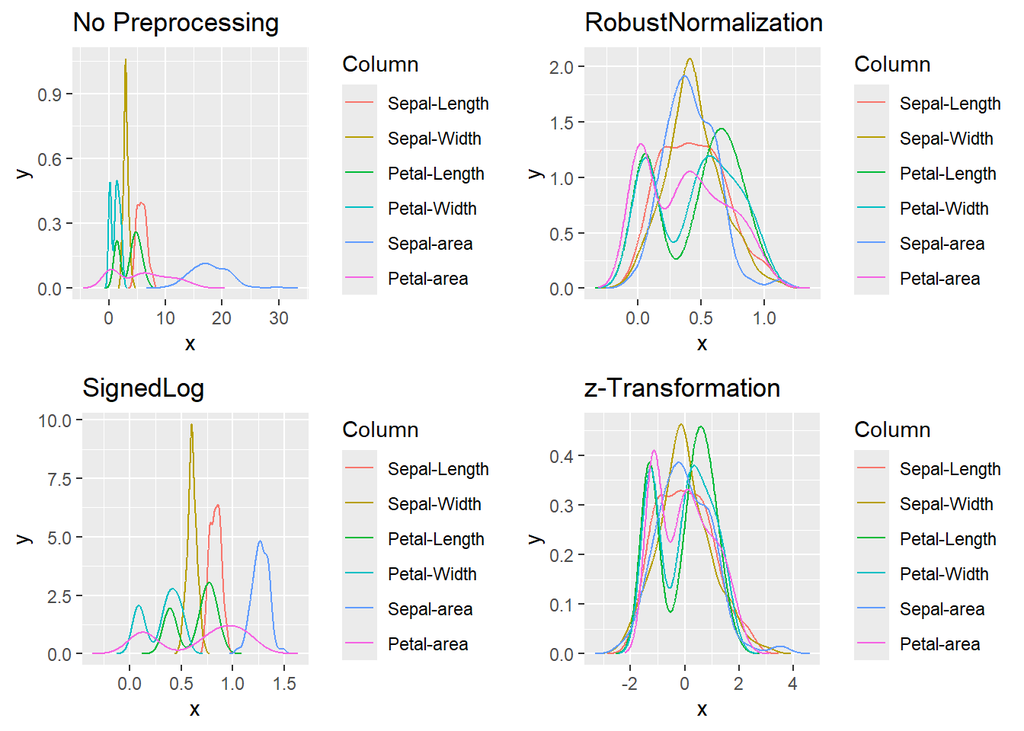

A quick peak at the data before and after preprocessing. As one can easily see all different preprocessing methods used work well, with SignedLog transforming the data more towards a normal distribution (especially Sepal-Lenght, compared to the others), Robust Normalization making the data generally smoother and z-Transformation scaling towards a mean of 0 with a sd of 1 for better comparisson of features.

### Comparisson Crabs Data

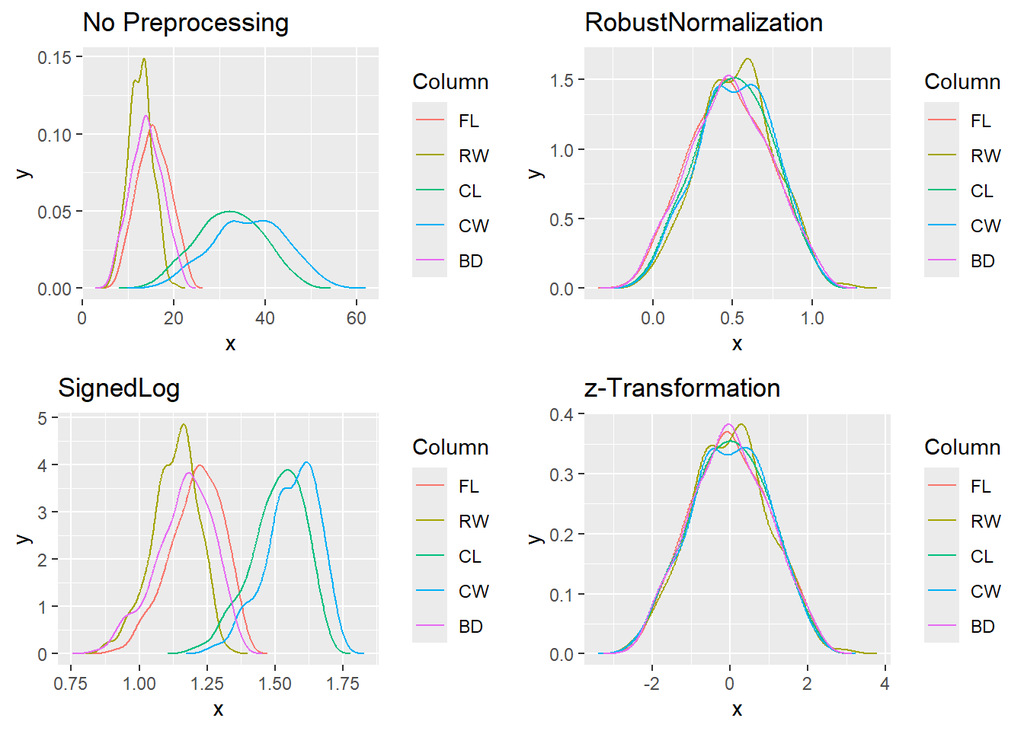

## 2. Clustering with ESOM

### Clustering of the Iris Data set

We chose to use SignedLog preprocessing because it generates the clearest cutoff between clusters.

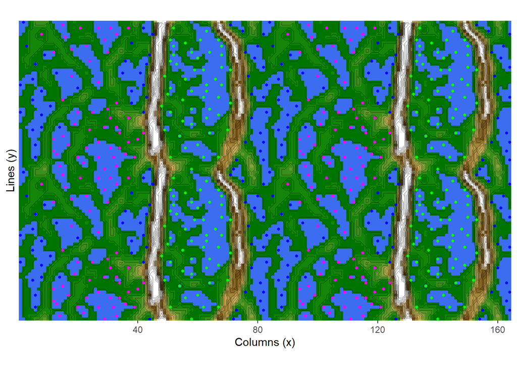

If not for the colors of the solution only two clusters would be visibly identifiable. While the green cluster is clearly separated, blue and pink seem to overlap, with no “mountains” for separation

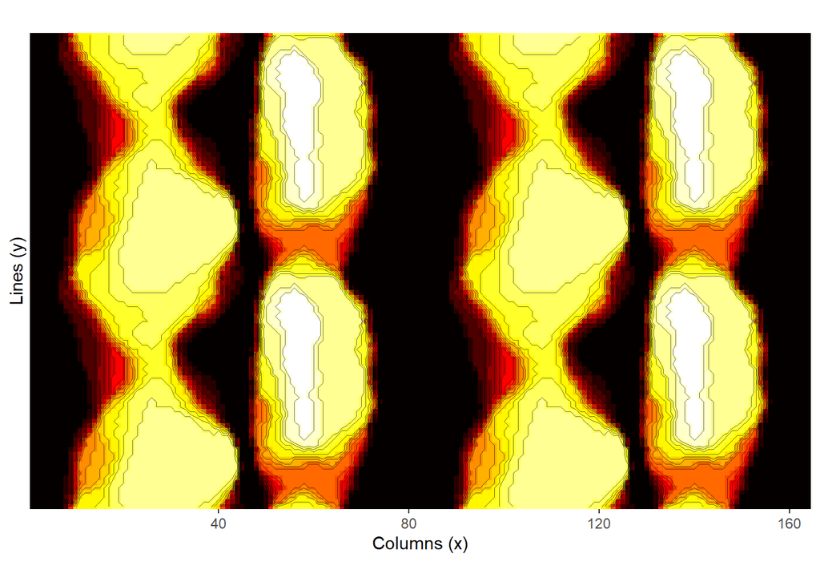

There seems to be a difference in density between the blue and pink clusters if visually compared to the former uMap. To make this clearer a UStar Matrix is generated:

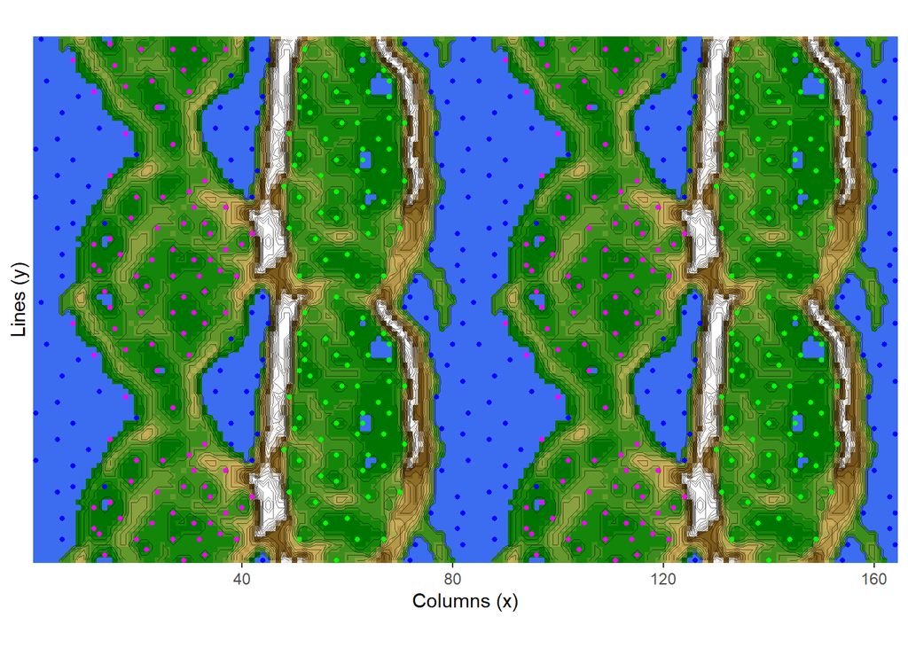

Here one could differentiate three clusters: the green one in the valley between the high mountains, blue for all points in a lake and pink for the remaining valley floor close to water

We used Robust Normalization on the data as the other preprocessing methods did not improve the result

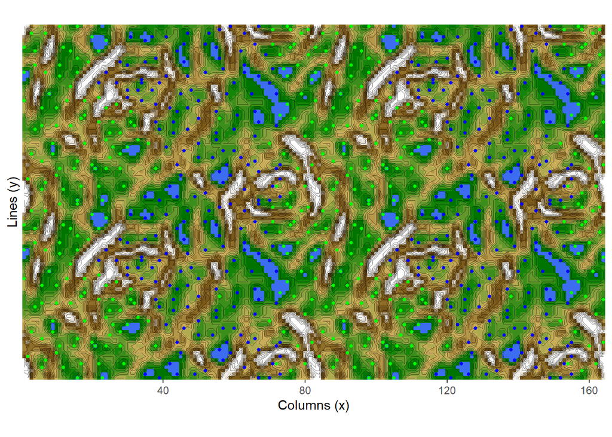

Highlighted in the map above are the two different sexes

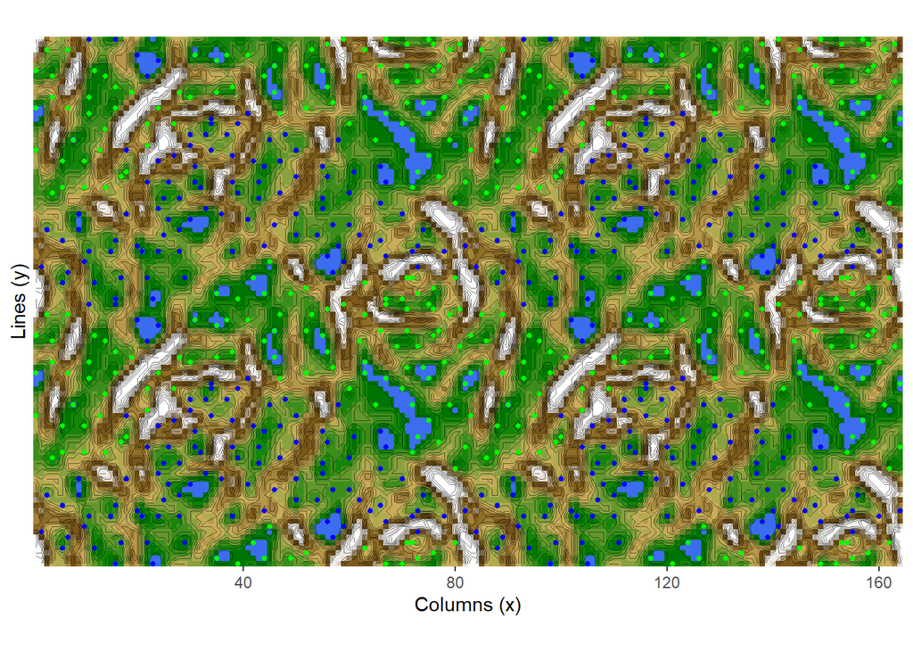

There are no detectable clusters in any shape or form. Highlighted in the map above are the two different species

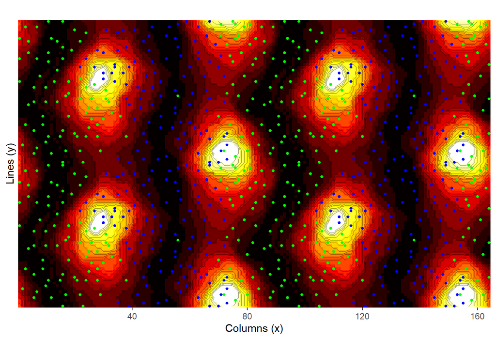

The pMatrix highlights two high density and two low density areas. If one takes the dark areas as clusters, it might just fit the clusters for sex, although it clearly does not help for species (below):

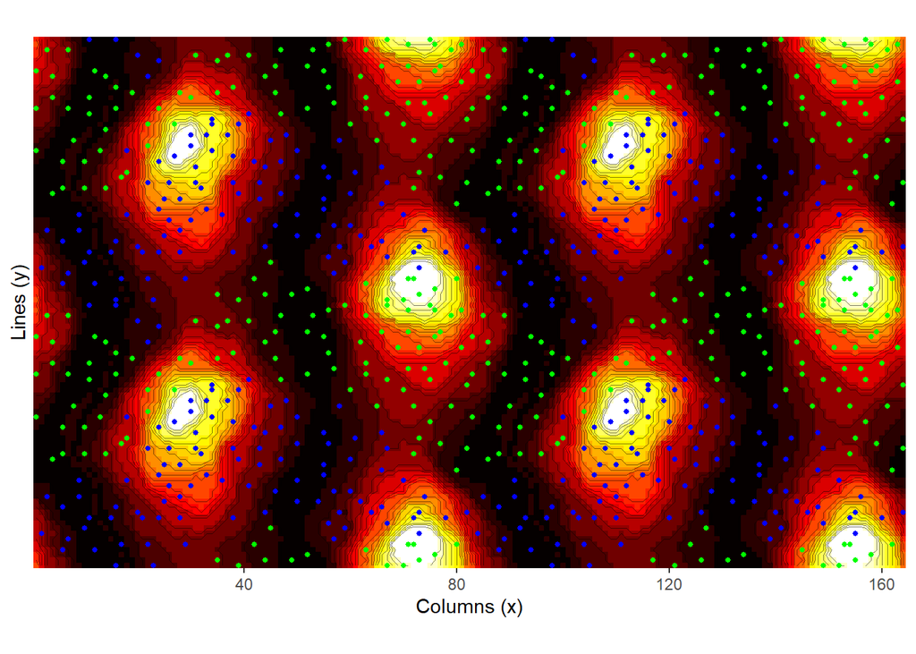

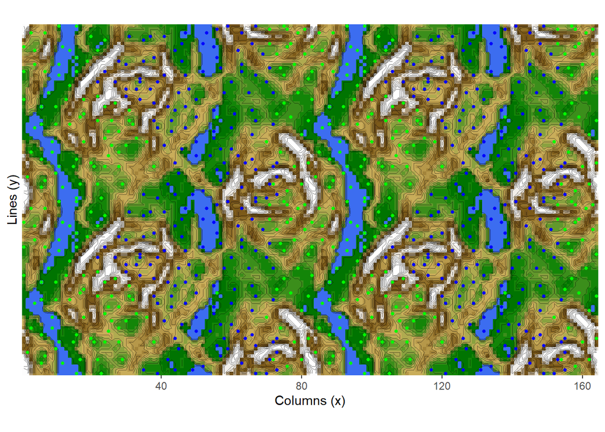

even combined u- and pMatrix don`t help find any clusters, with the highlights (in this case sex) one could argue for some mountains as division between clusters but difficult to impossible without. Even more so if one highlights species as shown below:

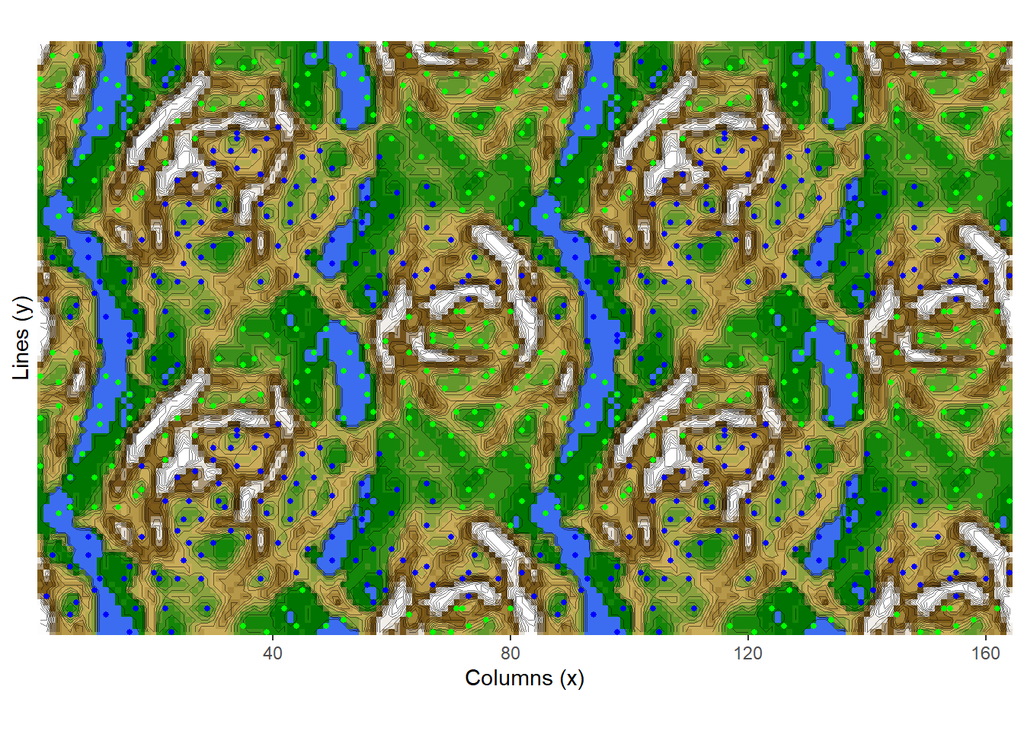

This difficulty in finding anything might be caused by some overlap in the data, eg when one of the species females are the same size as another species males. Although when looking at the p- and U*-Map there seems to be a slight trend toward at least splitting between the sexes

3. Clustering with DBS

We now use Pswarm on the iris_sl, the seperation for the green cluster is clearly visable, while the blue and pink cluster slightly overlap.

```
## Package 'DatabionicSwarm' version 2.0.0.
```

```
## [1] "Initialization phase successful (Time: 0.12 secs)."
## [1] "Starting swarm game ..."
## [1] "Swarm computation ended (Time: 2.48 secs)."
## [1] "Adjusting ..."
```

```
## Lade nötigen Namensraum: mgcv
```

[output not shown]

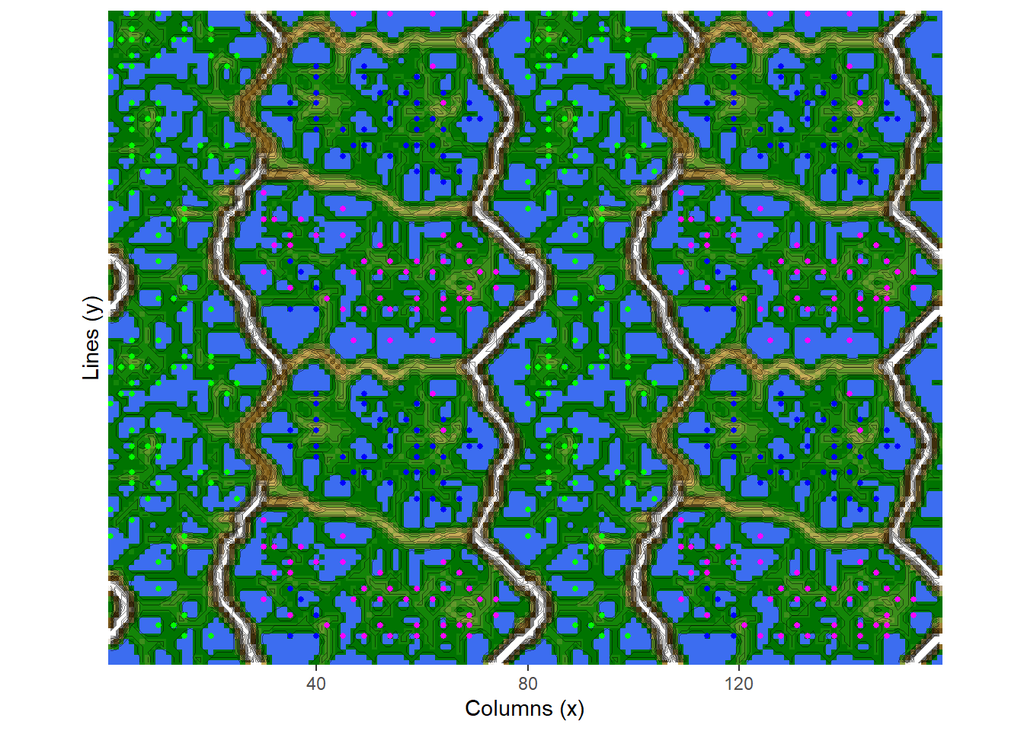

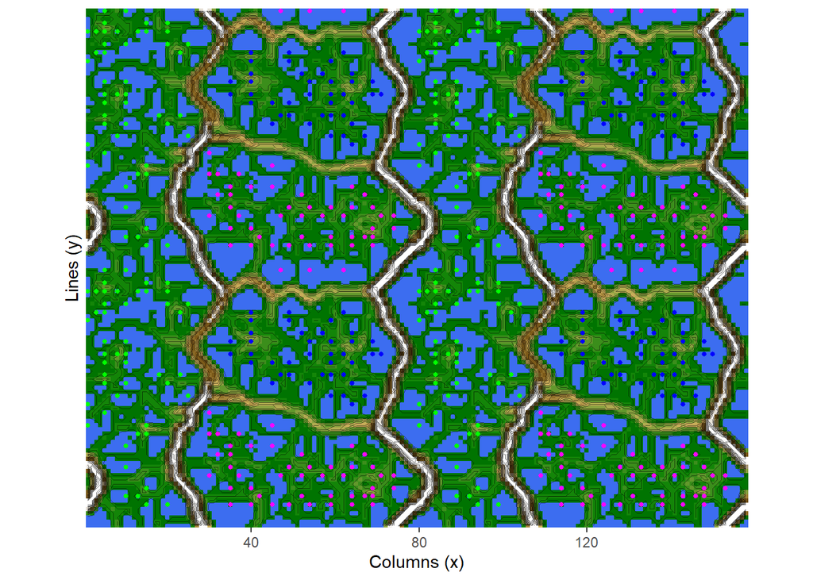

```r
dbs <- DBSclustering(3,iris_sl,s$Bestmatches,c(s$Lines,s$Columns))
plotMatrix(s$Umatrix,s$Bestmatches,Cls = dbs)
```

```r
crabs_pswarm <- Pswarm(crabs_pp)
```

```
## [1] "Initialization phase successful (Time: 0.01 secs)."
## [1] "Starting swarm game ..."
## [1] "Swarm computation ended (Time: 6.39 secs)."
## [1] "Adjusting ..."
```

```r
crabs_s <- GeneralizedUmatrix::GeneralizedUmatrix(crabs_pp,crabs_pswarm$ProjectedPoints)
```

[output not shown]

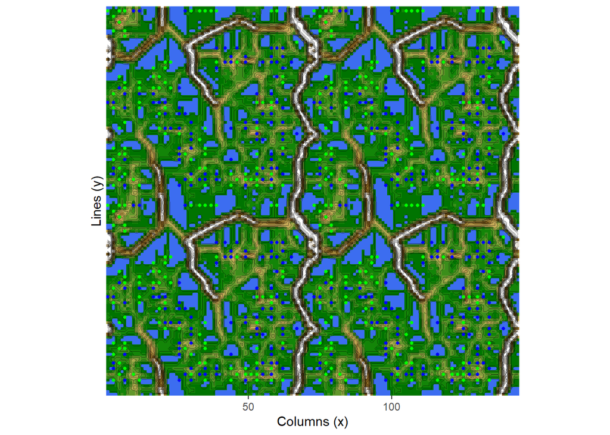

```r
plotMatrix(crabs_s$Umatrix,crabs_s$Bestmatches, Cls = crabs_sp$Cls)
```

For the crabs dataset the results with pswarm seem worse, in the image above the two classes are the species

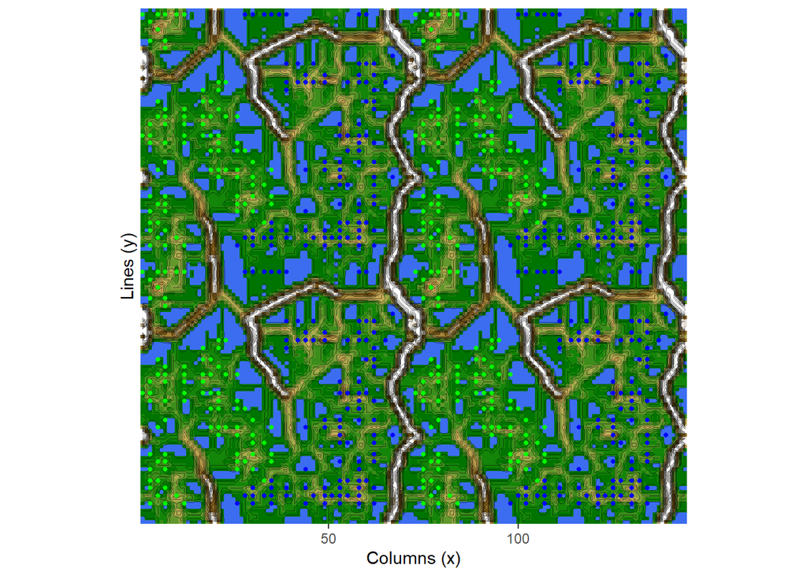

```r
crabs_dbs <- DBSclustering(2,crabs_pp,crabs_s$Bestmatches,c(crabs_s$Lines,crabs_s$Columns))
plotMatrix(crabs_s$Umatrix,crabs_s$Bestmatches,Cls = crabs_dbs)
```

Using DBSclustering give us a better seperation for the two species while there is still a bit of overlapping

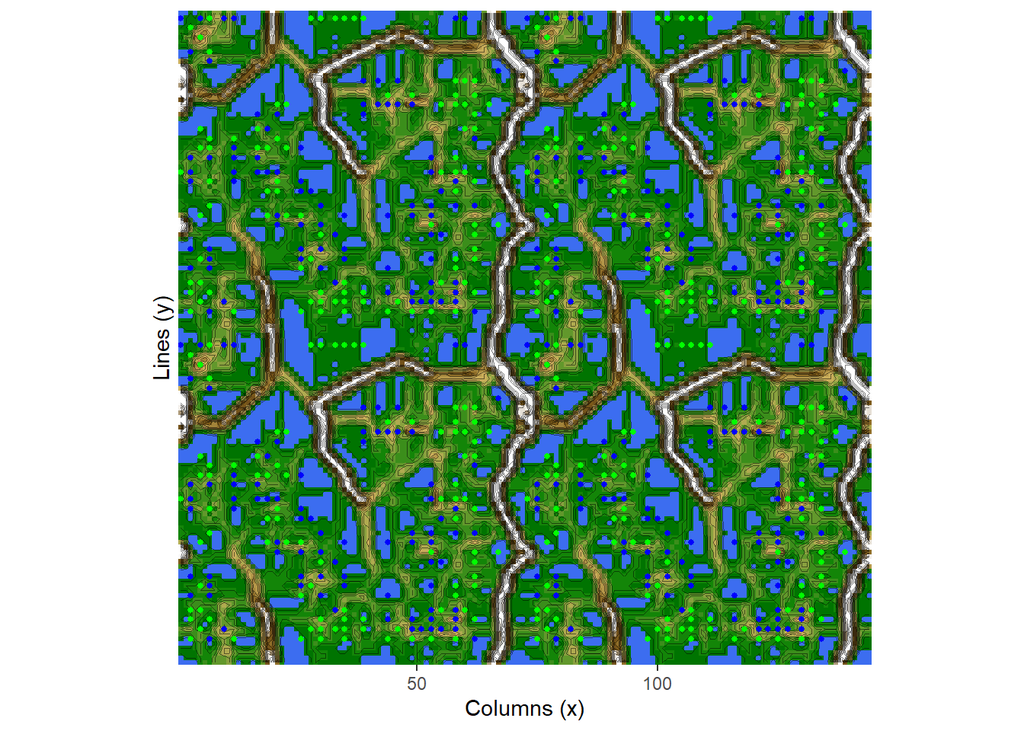

```r
plotMatrix(crabs_s$Umatrix,crabs_s$Bestmatches, Cls = crabs_sex$Cls)
```

For the sex attribute there is no visable seperation, this indicates that species can be better seperated then the sex attribute.

4. Evaluate match between classification and clustering

```r
caret::confusionMatrix(as.factor(dbs),as.factor(iris_solution$Cls))
```

```
## Confusion Matrix and Statistics
##
##           Reference
## Prediction  1  2  3
##          1 50  0  0
##          2  0 42  2
##          3  0  8 48
##
## Overall Statistics
##
##                Accuracy : 0.9333
##                  95% CI : (0.8808, 0.9676)
##     No Information Rate : 0.3333
##     P-Value [Acc > NIR] : < 2.2e-16
##
##                   Kappa : 0.9
##
##  Mcnemar's Test P-Value : NA
##
## Statistics by Class:
##
##                      Class: 1 Class: 2 Class: 3
## Sensitivity            1.0000   0.8400   0.9600
## Specificity            1.0000   0.9800   0.9200
## Pos Pred Value         1.0000   0.9545   0.8571
## Neg Pred Value         1.0000   0.9245   0.9787
## Prevalence             0.3333   0.3333   0.3333
## Detection Rate         0.3333   0.2800   0.3200
## Detection Prevalence   0.3333   0.2933   0.3733
## Balanced Accuracy      1.0000   0.9100   0.9400
```

```r
caret::confusionMatrix(as.factor(crabs_dbs),as.factor(crabs_sp$Cls))
```

```
## Confusion Matrix and Statistics
##
##           Reference
## Prediction  1  2
##          1 59 35
##          2 41 65
##
##                Accuracy : 0.62
##                  95% CI : (0.5489, 0.6875)
##     No Information Rate : 0.5
##     P-Value [Acc > NIR] : 0.0004225
##
##                   Kappa : 0.24
##
##  Mcnemar's Test P-Value : 0.5662796
##
##             Sensitivity : 0.5900
##             Specificity : 0.6500
##          Pos Pred Value : 0.6277
##          Neg Pred Value : 0.6132
##              Prevalence : 0.5000
##          Detection Rate : 0.2950
##    Detection Prevalence : 0.4700
##       Balanced Accuracy : 0.6200
##
##        'Positive' Class : 1
##
```

```r
caret::confusionMatrix(as.factor(crabs_dbs),as.factor(crabs_sex$Cls))
```

```
## Confusion Matrix and Statistics
##
##           Reference
## Prediction  1  2
##          1 41 53
##          2 59 47
##
##                Accuracy : 0.44
##                  95% CI : (0.3701, 0.5117)
##     No Information Rate : 0.5
##     P-Value [Acc > NIR] : 0.9616
##
##                   Kappa : -0.12
##
##  Mcnemar's Test P-Value : 0.6366
##
##             Sensitivity : 0.4100
##             Specificity : 0.4700
##          Pos Pred Value : 0.4362
##          Neg Pred Value : 0.4434
##              Prevalence : 0.5000
##          Detection Rate : 0.2050
##    Detection Prevalence : 0.4700
##       Balanced Accuracy : 0.4400
##
##        'Positive' Class : 1
##
```